# GOA OROX Variance Comparison

Cindy Tribuzio

7/15/2021

# Description

Design based estimates of survey biomass are provided by the Groundfish Assessment Program (GAP) for individual species. However, in cases where there are rare or limited data, a species biomass is not estimated. In the case of the Gulf of Alaska (GOA) Other Rockfish stock complex (OROX), three species which are part of the complex do not have estimates of biomass created by GAP (blackgill, bocaccio, and stripetail rockfish). To address this, the assessment author copied the design based estimator method used by the GAP to create estimates of biomass for those species.

A second consideration is if it is appropriate to simply sum the individual species biomasses and variances to create the biomass and variance for the natural mortality (M) groupings using the stock assessment. The current GOA OROX assessment creates a new designed based estimate of biomass and variance for the whole M group by combining the individual species survey data and treating as a single species, as opposed to summing the individual species, which is the method used in other assessments.

This document will examine: 1) are there differences in the GAP estimates and those created by the assessment author for individual species; and 2) is there a difference between summing the biomass and variances or estimating M group level values.

## Individual species comparison

| RACE_code | Group |
| --- | --- |
| 30100 | silvergray rockfish |
| 30170 | darkblotched rockfish |
| 30190 | splitnose rockfish |
| 30200 | greenstriped rockfish |
| 30220 | widow rockfish |
| 30240 | yellowtail rockfish |
| 30350 | vermilion rockfish |
| 30430 | redstripe rockfish |
| 30470 | yelloweye rockfish |
| 30475 | redbanded rockfish |

[output cut: 4 more lines]

The GAP estimates are compared to those created by the OROX assessment code:

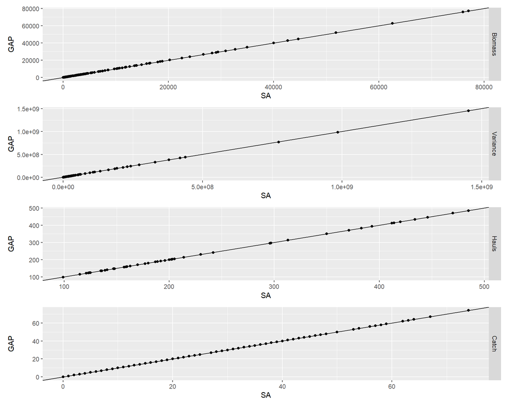

## Summing vs. Re-estimating

Biomass estimates were created for each of the M groups used in the GOA OROX stock assessment using the current assessment methods and ONLY species in which GAP provides estimates for. GAP estimates were summed for each M group to compare to the estimates using the current assessment methods.

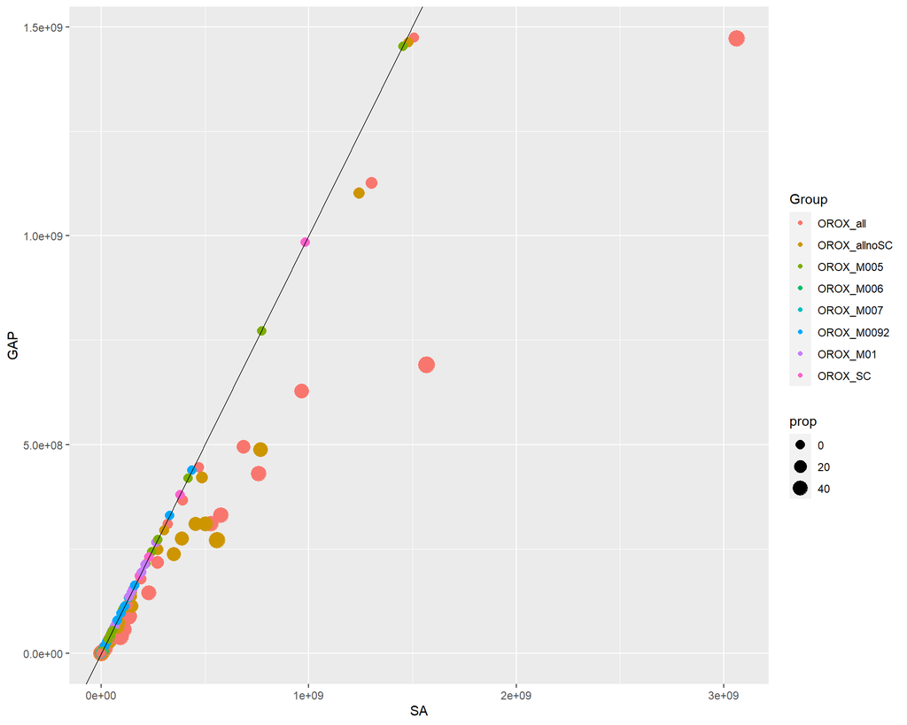

Figure shows the proportional difference that the GAP variance is from the assessment estimated variance. Below table is ordered to highlight the groups with the biggest proportional difference. When estimating variance for a larger number of species, the difference between the assessment method and summing the GAP estimates are greater. Of note, the OROX_all is all Tier 5 species and sharpchin combined, which is not used for harvest recommendations. The OROX_allnoSC is all of the Tier 5 species only, which is used for ABC/OFL calculations and shown below.

| YEAR | REGULATORY_AREA_NAME | SA | GAP | Group | Vardiff | prop |
| --- | --- | --- | --- | --- | --- | --- |
| 1987 | WESTERN GOA | 9.439401e+07 | 3.962669e+07 | OROX_all | 5.476732e+07 | 58.02 |
| 1996 | EASTERN GOA | 1.567548e+09 | 6.908630e+08 | OROX_all | 8.766846e+08 | 55.93 |
| 1987 | EASTERN GOA | 3.062448e+09 | 1.473134e+09 | OROX_all | 1.589314e+09 | 51.90 |
| 1996 | EASTERN GOA | 5.583225e+08 | 2.715744e+08 | OROX_allnoSC | 2.867481e+08 | 51.36 |
| 1993 | CENTRAL GOA | 1.085707e+08 | 5.631455e+07 | OROX_all | 5.225612e+07 | 48.13 |
| 2019 | WESTERN GOA | 7.088675e+04 | 3.754108e+04 | OROX_all | 3.334567e+04 | 47.04 |
| 1996 | CENTRAL GOA | 7.580852e+06 | 4.189488e+06 | OROX_all | 3.391364e+06 | 44.74 |
| 1990 | EASTERN GOA | 7.580414e+08 | 4.305652e+08 | OROX_all | 3.274762e+08 | 43.20 |
| 1993 | EASTERN GOA | 5.753340e+08 | 3.314232e+08 | OROX_all | 2.439107e+08 | 42.39 |
| 2019 | WESTERN GOA | 8.323780e+03 | 4.867101e+03 | OROX_allnoSC | 3.456679e+03 | 41.53 |

[output cut: 366 more lines]

Below is the comparison of the RFX model outputs for the SA and the summed GAP methods.

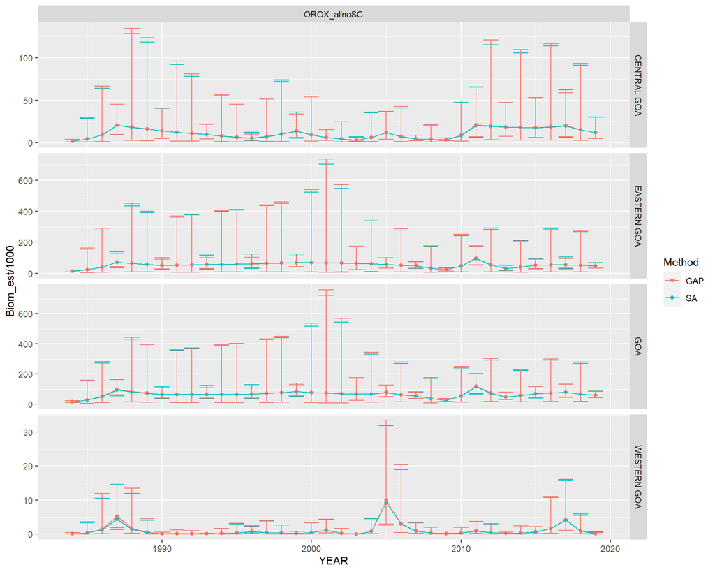

The above figure is filtered for the species group that is used for the ABC and OFL calculations. Appears to make little difference in the RFX output.

## ABC and OFLs as a result either method

There is little difference between the resultant ABCs when the GAP variances are summed compared to restimating the variance for each group.

| REG_AREA | GAP_ABC | SA_ABC |
| --- | --- | --- |
| CENTRAL GOA | 711.29556 | 711.38848 |
| GOA | 3582.05149 | 3580.68218 |
| WESTERN GOA | 10.41125 | 12.20556 |
| EYAK | 2549.18768 | 2546.28189 |
| WYAK | 311.15951 | 310.80482 |

## Does including those rare species matter?

| REG_AREA | Full_ABC | SA_ABC |
| --- | --- | --- |
| CENTRAL GOA | 711.81991 | 711.38848 |
| GOA | 3588.47643 | 3580.68218 |
| WESTERN GOA | 12.20494 | 12.20556 |
| EYAK | 2552.84855 | 2546.28189 |
| WYAK | 311.60637 | 310.80482 |